# RWFC

Guillaume

03/12/2020

## Fitness evolution

Evolution du fitness des 80 chromosomes, sur 1000 epoch.

### Fitness moyen et max

```
## [1] 0.5151459
```

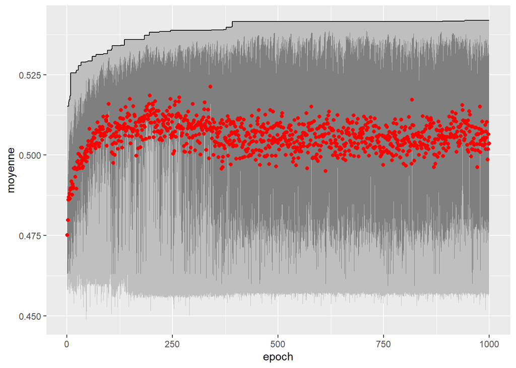

Evolution du fitness moyen des 80 chromosomes. Les 2336 valeurs en échec (-inf), soit 3% des valeurs, sont à NA et donc sorties de la moyenne. Sur les 100 derniers runs, le fitness moyen est de 0.5065219, le fitness max moyen est de 0.541803 et le fitness min moyen de 0.4564775

### Fitness global

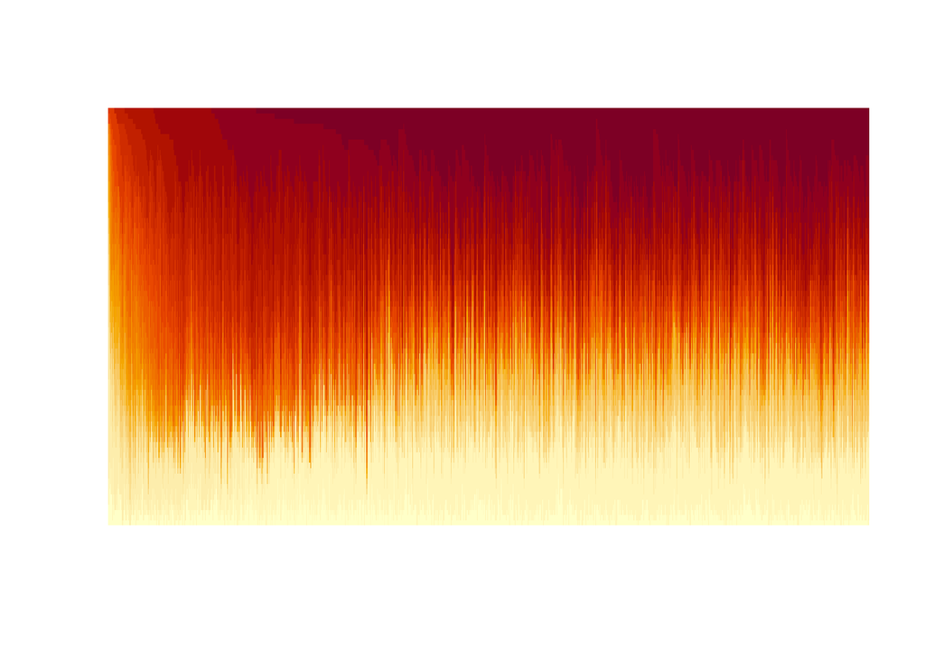

Evolution du fitness de tous les chromosomes. A chaque epoch, ils sont triés et les NA sont à la valeur de fitness minimale globale. Les 2336 valeurs en échec (-inf), soit 3% des valeurs, sont mises à la valeur minimale pour l’affichage graphique.

## Entropie

### Entropie des genes / zones

Affichage de l’entropie des 100 genes / zones. On ne tient pas compte de la rotation, juste du type de module choisi pour la zone. Plus l’entropie est faible pour une zone, plus l’ensemble des chromosome a choisi de forcer le meme module pour cette zone, a cet epoch.

#### Entropie moyenne

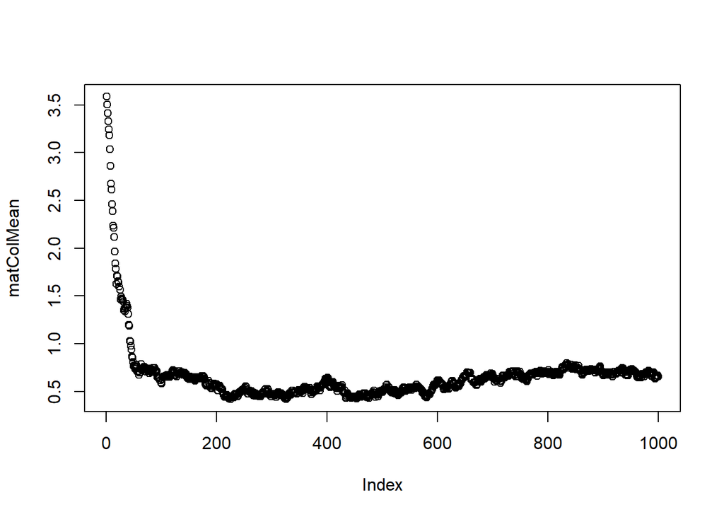

#### Entropie globale

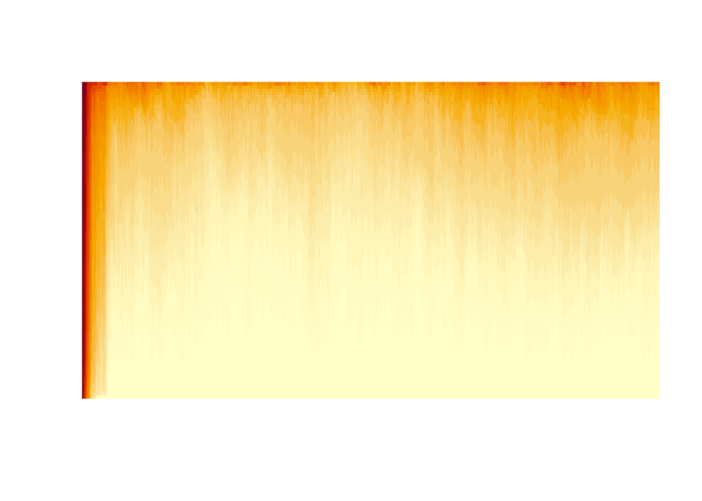

#### Entropie localisée

On peut affiche l’entropie sur une projection de la map, vue de dessus.

```
## [1] "Histogramme de l'entropie moyenne"
```

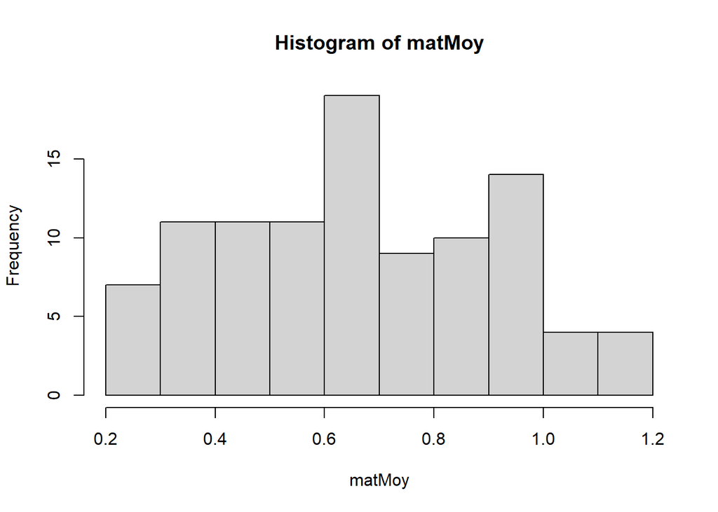

```
## [1] "Entropie moyenne projetée sur la carte"
```

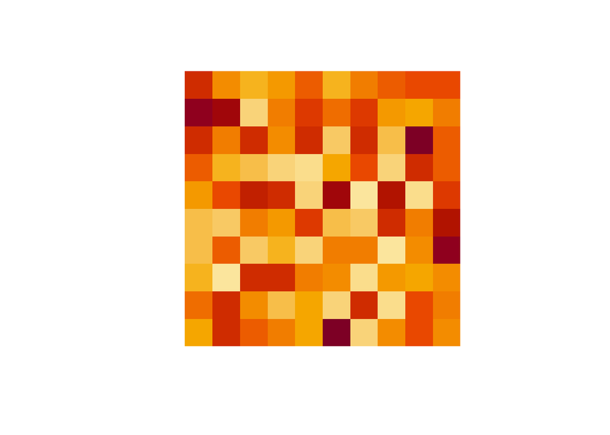

```
## [1] "Entropie moyenne projetée sur la carte tous les  200  epoch"
```

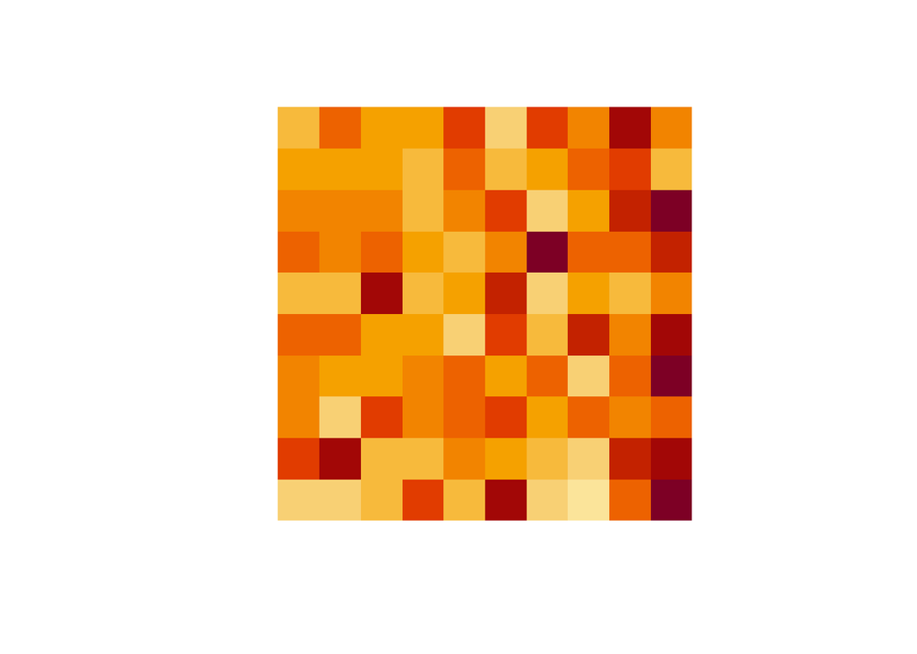

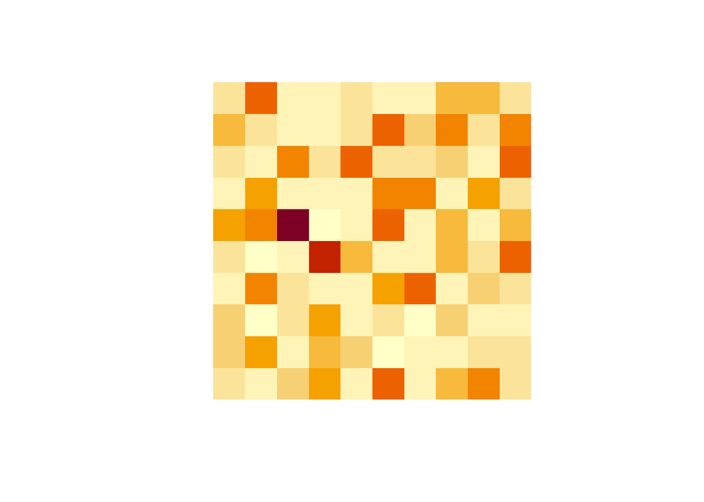

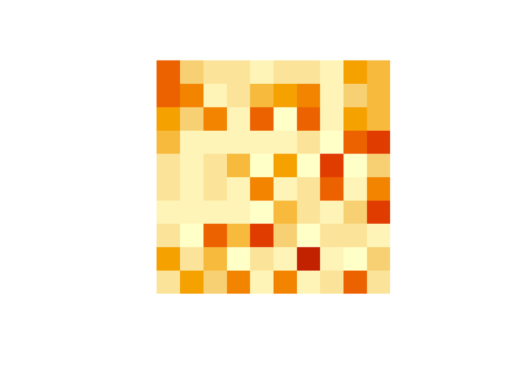

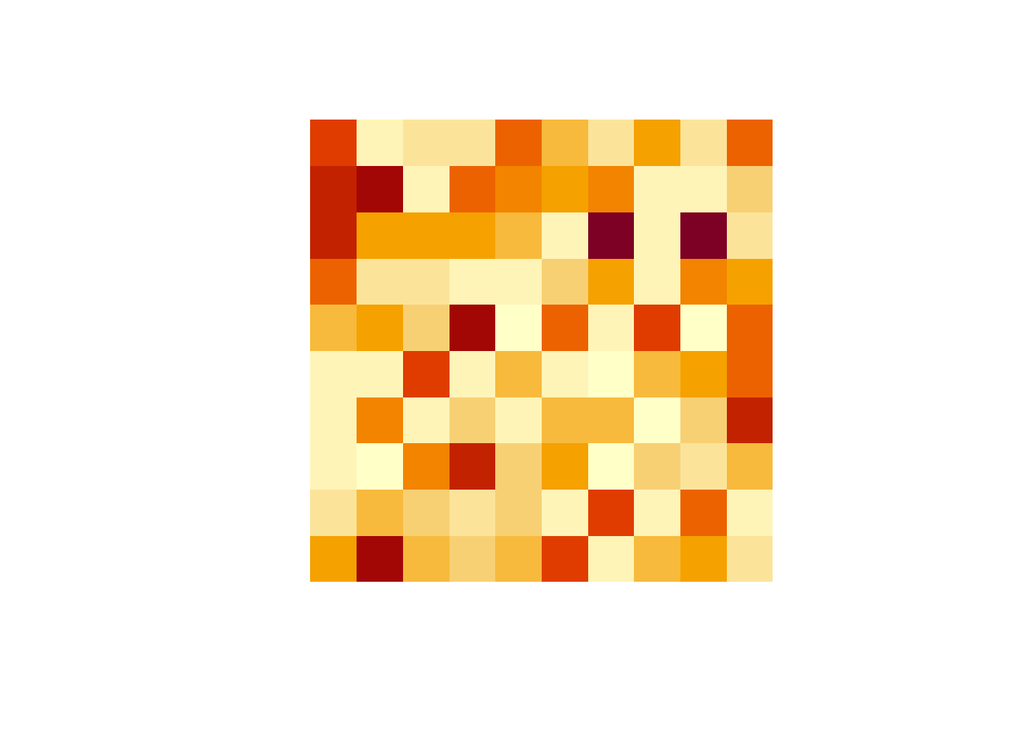

### Entropy modules (après WFC)

Affichage de l’entropie des 100 modules placés sur chaque zone de la carte. En effet, au dela du choix effecté par le gène, il y’a le WFC qui impose des contraintes et donc le module final n’est pas forcément celui choisi. Si l’entropie est faible pour une zone, c’est que après le WFC, tous les niveaux générés à un epoch on effectivement le même module.

#### Entropie moyenne

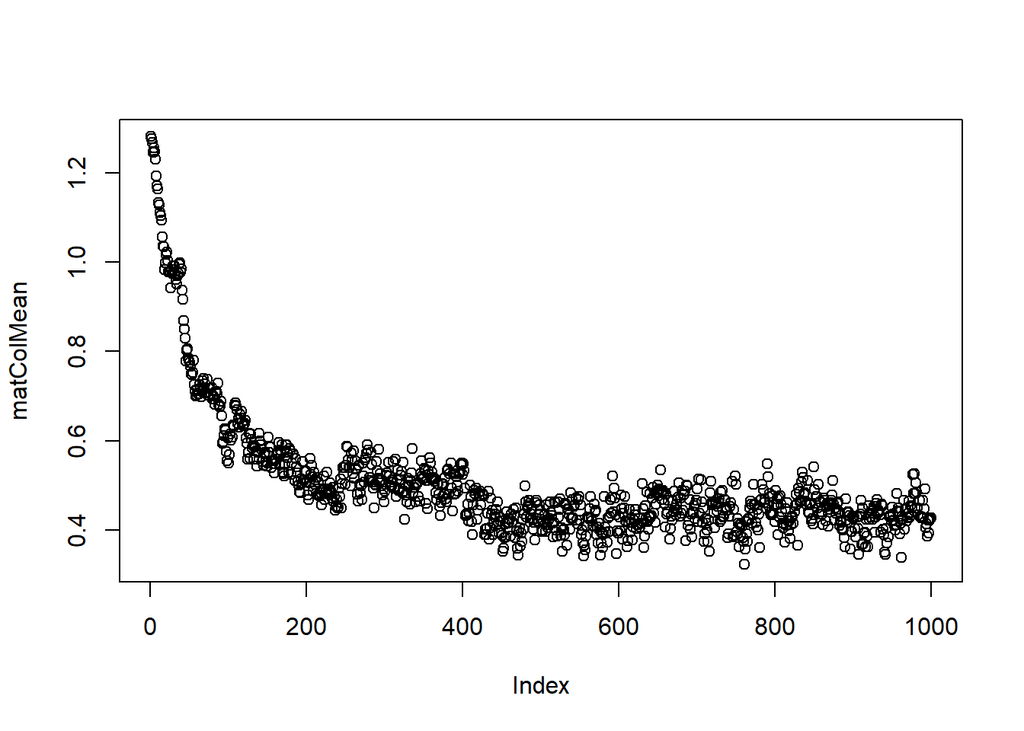

#### Entropie globale

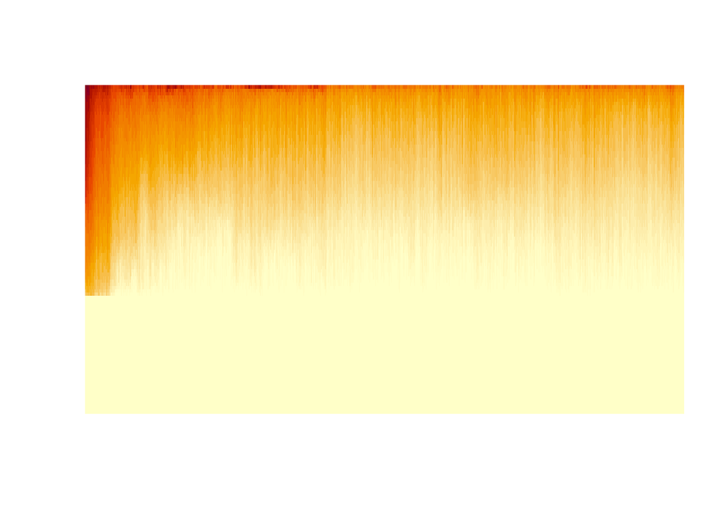

#### Entropie localisée

On peut affiche l’entropie sur une projection de la map, vue de dessus.

```
## [1] "Histogramme de l'entropie moyenne"
```

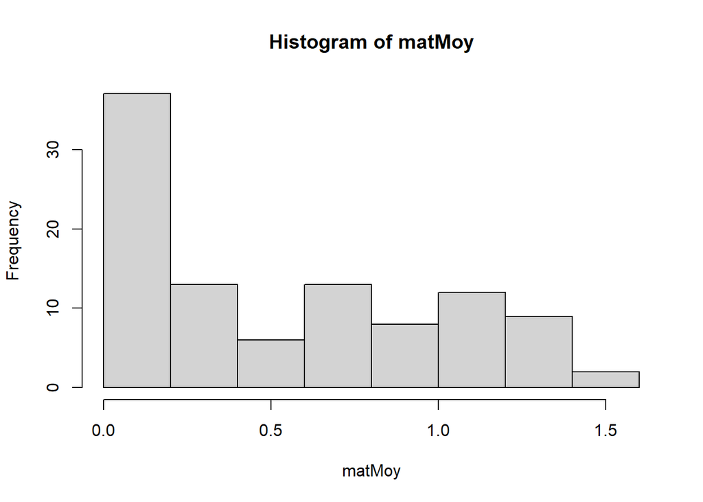

```
## [1] "Entropie moyenne projetée sur la carte"
```

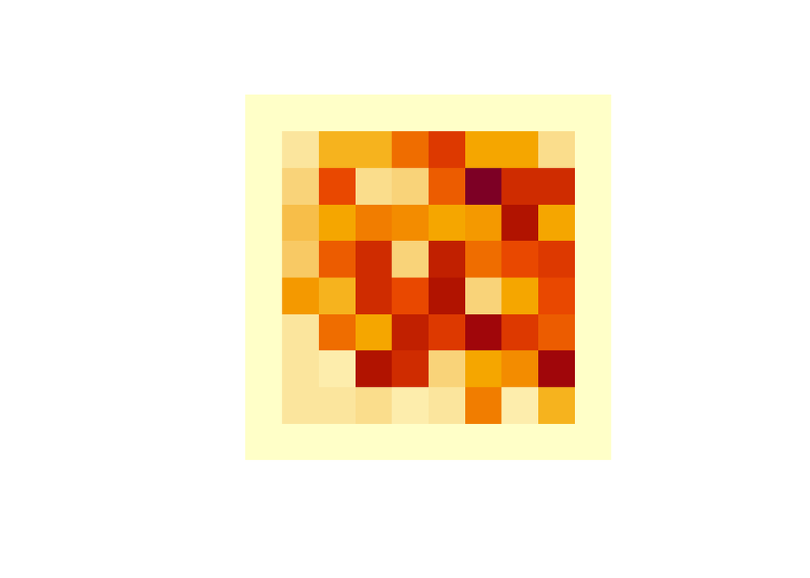

```
## [1] "Entropie moyenne projetée sur la carte tous les  200  epoch"
```

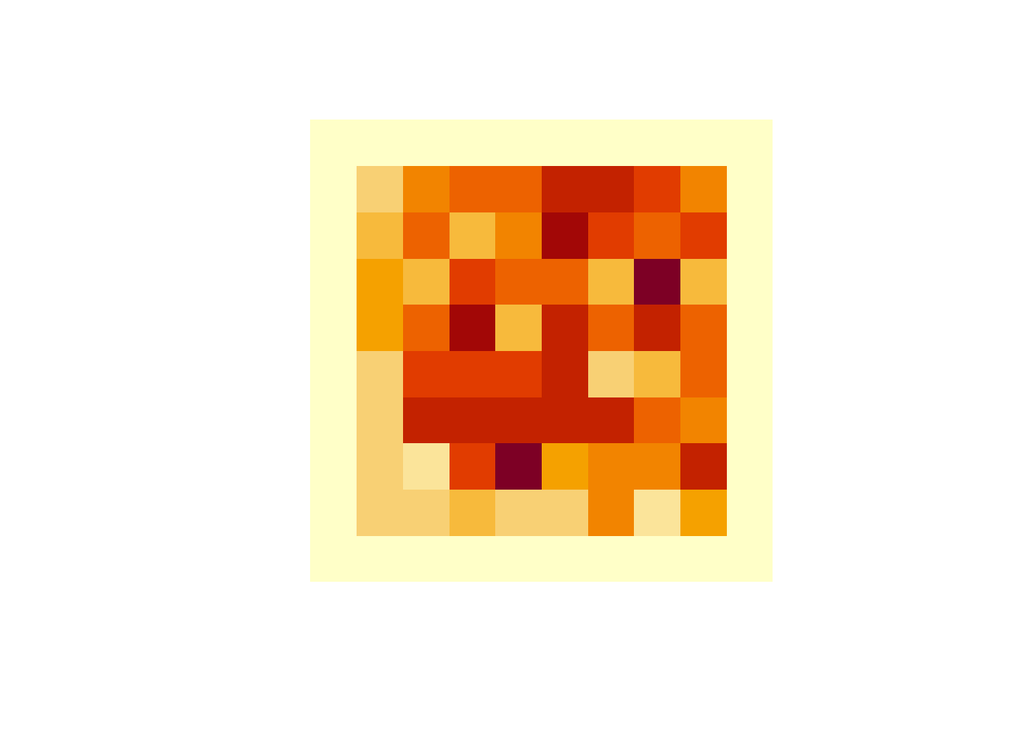

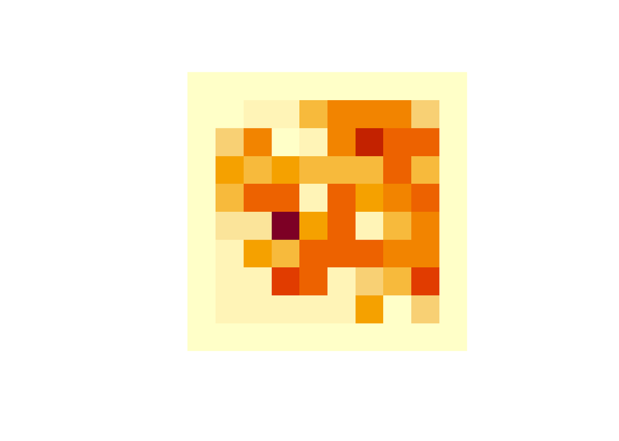

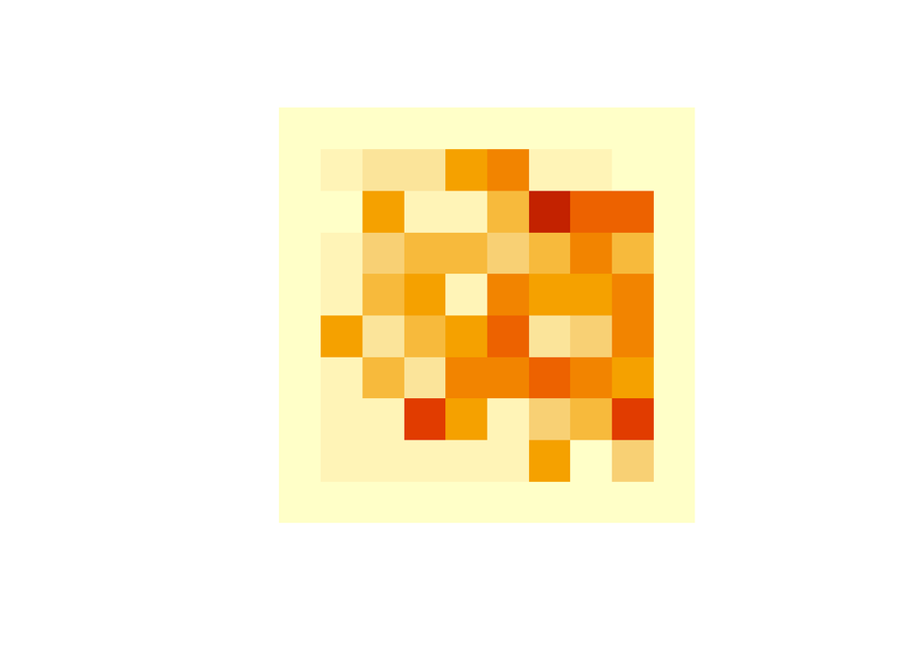

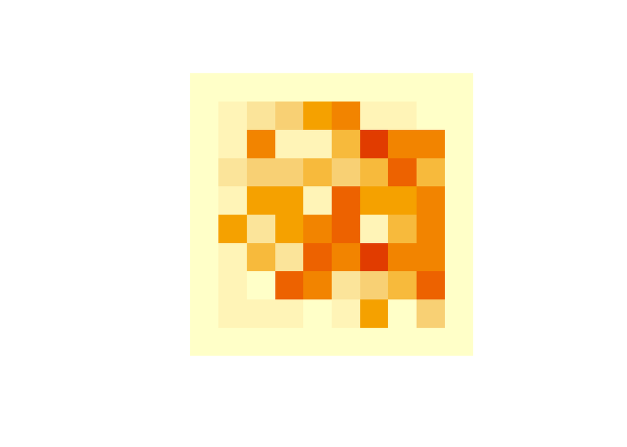